# ADE4とade4∆IDR株の生育曲線の解析

MT

2022-04-18

# 1 この事例で扱うデータと統計

# 2 データの取り込みと変換

```r
library(pacman)
p_load(tidyverse, openxlsx, ggsignif, readxl, knitr, nparcomp, rstatix)  # パッケージをまとめてロード
```

Excelファイルの読み込み。秒単位の時間`second`の列以外は、各サンプルのODの値が各列に相当する、ワイド形式のデータセット。

```r
tldata <- read_excel("220417_tl.xlsx",
                         sheet = "blank_corrected")
head(tldata)
```

```
## # A tibble: 6 × 97
##   second `wha-1` `wha-2` `wha-3` `wha-4` `wha-5` `wha-6` `mha-1` `mha-2` `mha-3`
##   <chr>    <dbl>   <dbl>   <dbl>   <dbl>   <dbl>   <dbl>   <dbl>   <dbl>   <dbl>
## 1 0(s)     0.032   0.031   0.035   0.03    0.032   0.033   0.033   0.031   0.03
## 2 608(s)   0.032   0.032   0.034   0.03    0.033   0.032   0.03    0.03    0.029
## 3 1204(…   0.032   0.033   0.034   0.031   0.032   0.031   0.029   0.029   0.027
## 4 1805(…   0.033   0.034   0.036   0.032   0.031   0.03    0.029   0.028   0.028
## 5 2404(…   0.032   0.035   0.037   0.034   0.034   0.03    0.027   0.029   0.028
## 6 3004(…   0.033   0.037   0.039   0.035   0.033   0.029   0.027   0.029   0.028
## # … with 87 more variables: `mha-4` <dbl>, `mha-5` <dbl>, `mha-6` <dbl>,
## #   B1 <dbl>, `wh-1` <dbl>, `wh-2` <dbl>, `wh-3` <dbl>, `wh-4` <dbl>,
## #   `wh-5` <dbl>, `wh-6` <dbl>, `mh-1` <dbl>, `mh-2` <dbl>, `mh-3` <dbl>,
## #   B11 <dbl>, B12 <dbl>, C1 <dbl>, `mh-4` <dbl>, `mh-5` <dbl>, `mh-6` <dbl>,
## #   `wl-1` <dbl>, `wl-2` <dbl>, `wl-3` <dbl>, `wl-4` <dbl>, `wl-5` <dbl>,
## #   `wl-6` <dbl>, C11 <dbl>, C12 <dbl>, D1 <dbl>, `ml-1` <dbl>, `ml-2` <dbl>,
## #   `ml-3` <dbl>, `ml-4` <dbl>, `ml-5` <dbl>, `ml-6` <dbl>, `wp-1` <dbl>, …
```

変数`second`の値から文字列`(s)`を除き、数値型に変換。データ全体をロング形式にする。

```r
# secondから"(s)"を除く、「(」はメタ文字なのでエスケープ、さらに数値型に変換
tldata <- tldata %>%
  mutate(second  = as.double(str_remove(second, "\\(s\\)"))) %>%
  # データを縦型にする
  pivot_longer(-second, names_to = "ID", values_to = "OD")
head(tldata)
```

```
## # A tibble: 6 × 3
##   second ID       OD
##    <dbl> <chr> <dbl>
## 1      0 wha-1 0.032
## 2      0 wha-2 0.031
## 3      0 wha-3 0.035
## 4      0 wha-4 0.03
## 5      0 wha-5 0.032
## 6      0 wha-6 0.033
```

変数`ID`の値の文字列を解析することで、変数`strain`, `nitrogen`, `adenine`を作成。また`second`から変数`hours`を作成。余分な行も除いておく。

```r
# 変数strainを追加する
tldata <- tldata %>%
  mutate(strain = case_when(
               str_detect(ID, "w") ~ "Ade4",
               str_detect(ID, "m") ~ "Ade4∆IDR",
               TRUE ~ "blank"
             ),
# 変数nitrogenを追加
         nitrogen = case_when(
               str_detect(ID, "h") ~ "38 mM AS",
               str_detect(ID, "l") ~ "1 mM AS",
               str_detect(ID, "p") ~ "8 mM proline"
         ),
# 変数adenineを追加
        adenine = case_when(
              str_detect(ID, "a") ~ "adenine(+)",
              TRUE ~ "adenine(-)"
        ),
# 変数hoursを追加
        hours = second / 3600) %>%
# blankの行は消去
  filter(strain != "blank")
```

IDの最後の数字を変数`replicate`に格納。また`nitrogen`のレベル順を規定しておく。

```r
tldata <- tldata %>%
  mutate(replicate = str_sub(ID, -1, -1))
levels(tldata$nitrogen)
```

```r
tldata$nitrogen <- fct_relevel(tldata$nitrogen, c("38 mM AS","1 mM AS","8 mM proline"))
tldata
```

```
## # A tibble: 30,744 × 8
##    second ID       OD strain   nitrogen adenine    hours replicate
##     <dbl> <chr> <dbl> <chr>    <fct>    <chr>      <dbl> <chr>
##  1      0 wha-1 0.032 Ade4     38 mM AS adenine(+)     0 1
##  2      0 wha-2 0.031 Ade4     38 mM AS adenine(+)     0 2
##  3      0 wha-3 0.035 Ade4     38 mM AS adenine(+)     0 3
##  4      0 wha-4 0.03  Ade4     38 mM AS adenine(+)     0 4
##  5      0 wha-5 0.032 Ade4     38 mM AS adenine(+)     0 5
##  6      0 wha-6 0.033 Ade4     38 mM AS adenine(+)     0 6
##  7      0 mha-1 0.033 Ade4∆IDR 38 mM AS adenine(+)     0 1
##  8      0 mha-2 0.031 Ade4∆IDR 38 mM AS adenine(+)     0 2
##  9      0 mha-3 0.03  Ade4∆IDR 38 mM AS adenine(+)     0 3
## 10      0 mha-4 0.033 Ade4∆IDR 38 mM AS adenine(+)     0 4
## # … with 30,734 more rows
```

ODの値を最大値で正規化するため、40時間までの最大値`max`を計算してデータフレーム`max_40h`に格納。`left_join()`で`tldata`に`max`を組み合わせる。さらに`OD`を`max`で割り算して変数`nOD`を計算。

```r
# 40時間までの最大値を計算して変数maxに格納
max_40h <- tldata %>%
  group_by(strain, nitrogen, adenine, replicate) %>%
  filter(hours < 40) %>% summarise(max = max(OD))
tldata <- left_join(tldata, max_40h) %>%
  mutate(nOD = OD / max)
tldata
```

```
## # A tibble: 30,744 × 10
##    second ID       OD strain   nitrogen adenine    hours replicate   max    nOD
##     <dbl> <chr> <dbl> <chr>    <fct>    <chr>      <dbl> <chr>     <dbl>  <dbl>
##  1      0 wha-1 0.032 Ade4     38 mM AS adenine(+)     0 1          1.21 0.0264
##  2      0 wha-2 0.031 Ade4     38 mM AS adenine(+)     0 2          1.26 0.0245
##  3      0 wha-3 0.035 Ade4     38 mM AS adenine(+)     0 3          1.29 0.0271
##  4      0 wha-4 0.03  Ade4     38 mM AS adenine(+)     0 4          1.26 0.0238
##  5      0 wha-5 0.032 Ade4     38 mM AS adenine(+)     0 5          1.24 0.0259
##  6      0 wha-6 0.033 Ade4     38 mM AS adenine(+)     0 6          1.16 0.0284
##  7      0 mha-1 0.033 Ade4∆IDR 38 mM AS adenine(+)     0 1          1.14 0.0290
##  8      0 mha-2 0.031 Ade4∆IDR 38 mM AS adenine(+)     0 2          1.20 0.0258
##  9      0 mha-3 0.03  Ade4∆IDR 38 mM AS adenine(+)     0 3          1.19 0.0251
## 10      0 mha-4 0.033 Ade4∆IDR 38 mM AS adenine(+)     0 4          1.25 0.0263
## # … with 30,734 more rows
```

# 3 生育曲線の描画

全体の生データの傾向をプロットして観察。

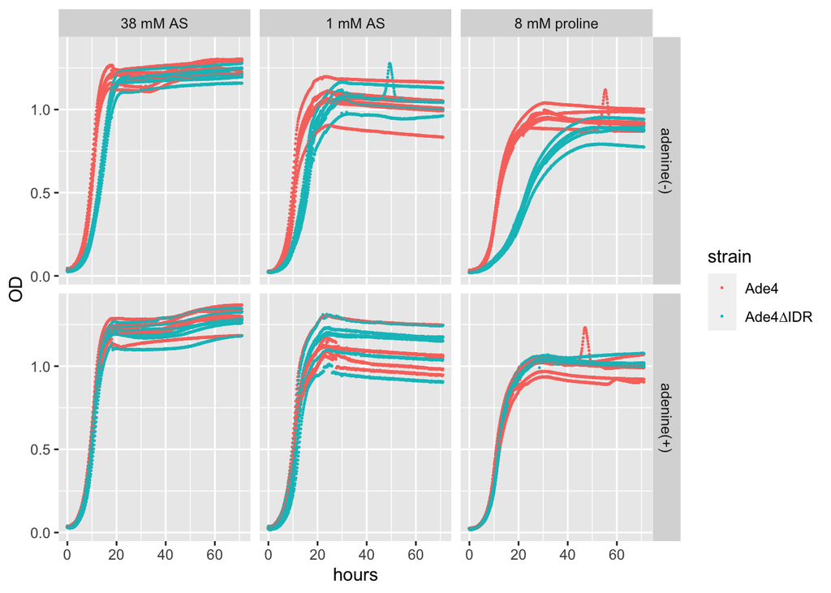

```r
tldata %>%
  ggplot(aes(x = hours, y = OD, color = strain)) +
  geom_point(size = 0.2) +
  facet_grid(adenine ~ nitrogen)
```

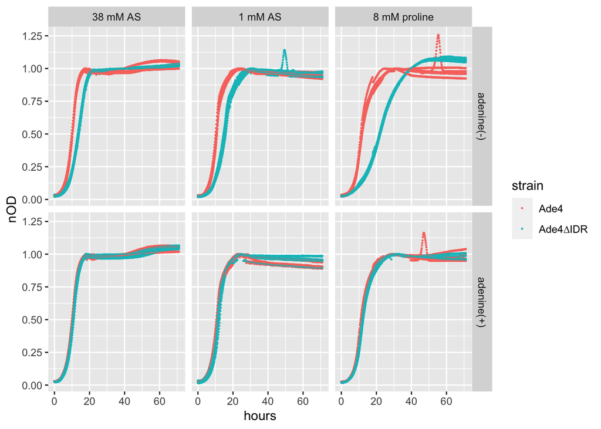

```r
#  nODの場合
tldata %>%
  ggplot(aes(x = hours, y = nOD, color = strain)) +
  geom_point(size = 0.2) +
  facet_grid(adenine ~ nitrogen)
```

`replicate`で平均化したgrowth curveを描く。

```r
# 平均値とSDの計算
mean_sd <- tldata %>%
  group_by(hours,strain, nitrogen, adenine) %>%
  summarise(mean = mean(nOD), sd = sd(nOD))
```

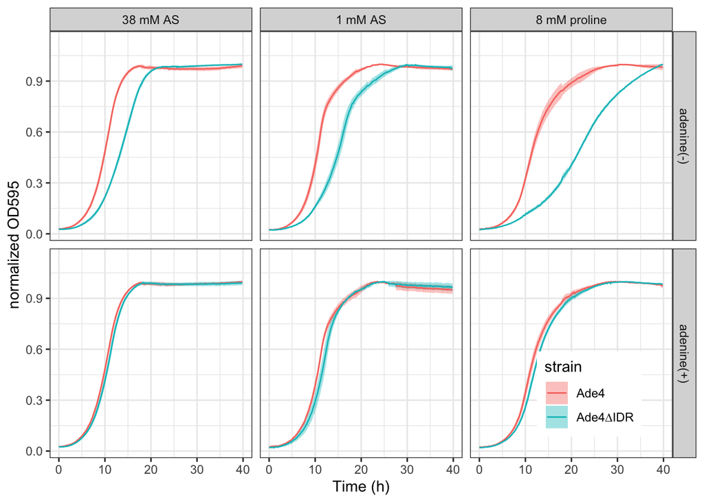

```r
meanplot <- mean_sd %>% ggplot(aes(x=hours, y= mean)) +
  # geom_ribbonである範囲の陰影を描く、fillで"grey70"のように直接色を指定することもできる
  geom_ribbon(aes(ymin=mean-sd, ymax=mean+sd,fill=strain), alpha=0.4) +
  geom_line(aes(colour=strain))+
  xlab("Time (h)") +
  ylab("normalized OD595")+
  xlim(0 ,40)+
  theme_bw()+
  facet_grid(adenine ~ nitrogen)

meanplot +
  theme(legend.position = c(0.95,0.05), legend.justification =c(1,0))
```

```r
# legend.positionで凡例の位置を変える、グラフ内に入れる場合は座標位置を指定、左下がc(0,0)で右上がc(1,1)
# 凡例ボックスのどの位置をlegend.positionに配置するかはlegend.justificationで指定する
```

`adenine`の値で別々にプロット。

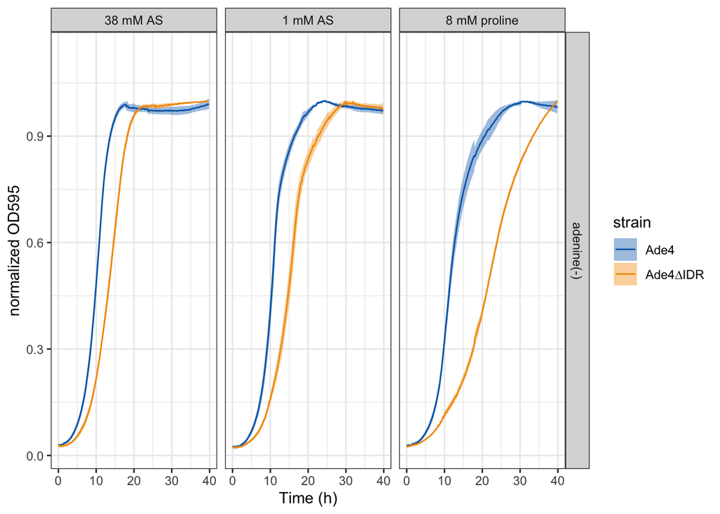

```r
# adenine(-)の場合
meanplot_woade <- mean_sd %>%
  filter(adenine == "adenine(-)") %>% ggplot(aes(x=hours, y= mean)) +
  geom_ribbon(aes(ymin=mean-sd, ymax=mean+sd,fill=strain), alpha=0.4)+ #
  geom_line(aes(colour=strain))+
  scale_fill_manual(values = c("#0068b7","#f39800")) +  # fillの色を直接指定
  scale_color_manual(values = c("#0068b7","#f39800")) + # color（線）の色を直接指定
  xlab("Time (h)") +
  ylab("normalized OD595")+
  xlim(0 ,40)+
  theme_bw()+
  facet_grid(adenine~ nitrogen)
meanplot_woade
```

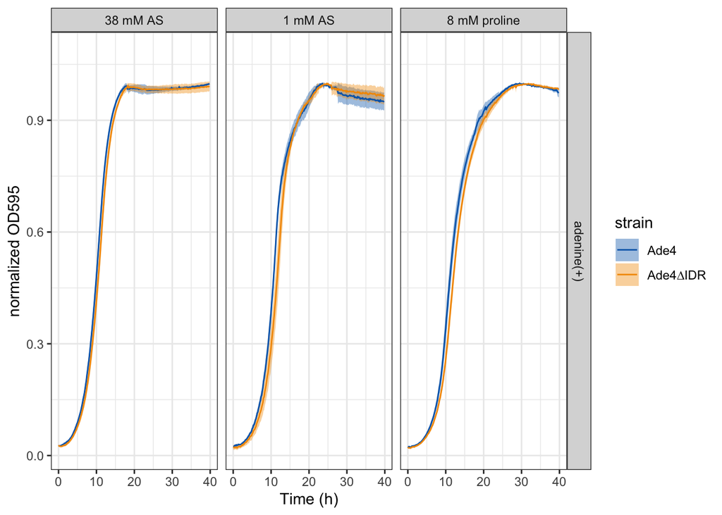

```r
meanplot_wade <- mean_sd %>%
  filter(adenine == "adenine(+)") %>% ggplot(aes(x=hours, y= mean)) +
  geom_ribbon(aes(ymin=mean-sd, ymax=mean+sd,fill=strain), alpha=0.4)+ #
  geom_line(aes(colour=strain))+
  scale_fill_manual(values = c("#0068b7","#f39800")) +  # fillの色を直接指定
  scale_color_manual(values = c("#0068b7","#f39800")) + # color（線）の色を直接指定
  xlab("Time (h)") +
  ylab("normalized OD595")+
  xlim(0 ,40)+
  theme_bw()+
  facet_grid(adenine~ nitrogen)
meanplot_wade
```

# 4 データの定量的解析

各条件における生育曲線の違いを定量的に解析するため、増殖が最大値の半分になる時間`halfmaxtime`を導入する。`nOD`が0.5以下の、`hours`の最大値が`halfmaxtime`に相当する。

```r
# nODが0.5になる時間を求める
halfmaxtime <- tldata %>%
  group_by(strain, nitrogen, adenine, replicate) %>%
  filter(nOD <= 0.5) %>%
  summarise(halfmaxtime = max(hours))
```

`halfmaxtime`の平均とSDを計算。

```r
mean_halfmaxtime <- halfmaxtime %>%
  group_by(strain, nitrogen, adenine) %>%
  summarise(mean_ht = mean(halfmaxtime), sd_ht = sd(halfmaxtime))
```

`halfmaxtime`の平均値とSD、および各データポイントをプロット。さしあたってWelch t-testで両側検定したp値も描画。

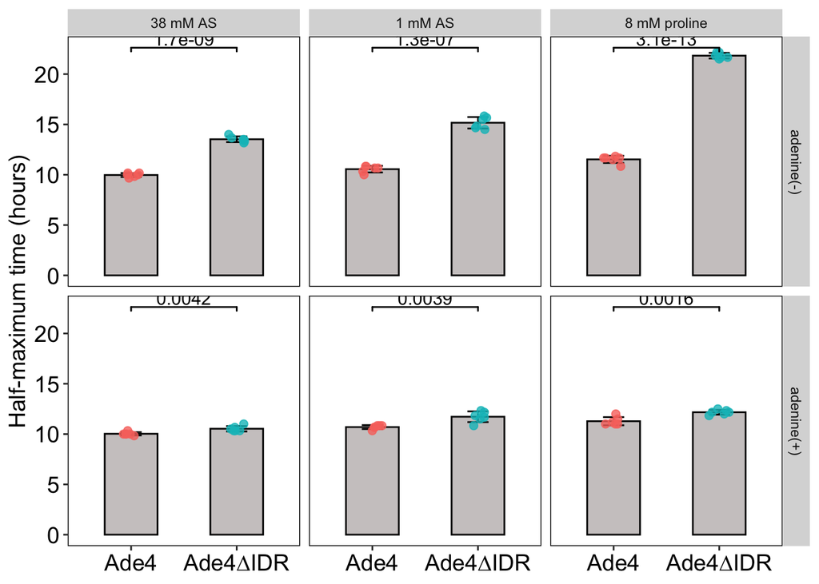

```r
mean_halfmaxtime %>% ggplot(aes(x = strain, y = mean_ht)) +
  geom_col(data = mean_halfmaxtime,color="black", fill = "snow3", width = 0.5)+
  geom_errorbar(aes(ymin = mean_ht - sd_ht, ymax = mean_ht + sd_ht, width = 0.2))+
  geom_jitter(halfmaxtime, mapping=aes(x=strain, y= halfmaxtime, color=strain),
              size = 2, alpha=0.8, height = 0, width = 0.1) +
  # height = 0にしないとy軸上に散らばり不正確になる
  # map_signif_levelはdefaultでFALSEであり、p値そのものが表示される
  geom_signif(data=halfmaxtime,mapping=aes(x=strain,y=halfmaxtime),
              comparisons = list(c("Ade4","Ade4∆IDR")),
               test.args= list(alternative = "two.sided", var.equal = FALSE, paired=F),
              test = "t.test", map_signif_level = FALSE, step_increase = 0, y_position = 22)+
  ylab("Half-maximum time (hours)") +
  xlab(NULL) +
  theme( axis.title.y = element_text(size=14), axis.text.y = element_text(size=14,color = "black"),
         axis.text.x = element_text(size=14,color = "black")
         ,legend.position = "none" #凡例を消す
         ,panel.border = element_rect(fill = NA, linewidth = 0.5)
         ,panel.background = element_blank())+
  facet_grid(adenine ~ nitrogen)
```

# 5 データの正規性の検証

`halfmaxtime`の分布が正規分布に従っているかどうか、Shapiro-Wilk検定で検証。各カテゴリ変数の組み合わせを表すデータフレームを作り、それを引数として`shapiro_test()`を実行。

```r
# 組み合わせ combを作成
strains <- c("Ade4", "Ade4∆IDR")
nitros <- levels(halfmaxtime$nitrogen)
ades <- c("adenine(-)", "adenine(+)")

comb <- expand.grid(strains, nitros, ades) %>%
  rename(strain = Var1, nitro = Var2, ade = Var3) %>%
  mutate(combination = paste(strain, nitro, ade, sep = "_"))
comb
```

```
##      strain        nitro        ade                      combination
## 1      Ade4     38 mM AS adenine(-)         Ade4_38 mM AS_adenine(-)
## 2  Ade4∆IDR     38 mM AS adenine(-)     Ade4∆IDR_38 mM AS_adenine(-)
## 3      Ade4      1 mM AS adenine(-)          Ade4_1 mM AS_adenine(-)
## 4  Ade4∆IDR      1 mM AS adenine(-)      Ade4∆IDR_1 mM AS_adenine(-)
## 5      Ade4 8 mM proline adenine(-)     Ade4_8 mM proline_adenine(-)
## 6  Ade4∆IDR 8 mM proline adenine(-) Ade4∆IDR_8 mM proline_adenine(-)
## 7      Ade4     38 mM AS adenine(+)         Ade4_38 mM AS_adenine(+)
## 8  Ade4∆IDR     38 mM AS adenine(+)     Ade4∆IDR_38 mM AS_adenine(+)
## 9      Ade4      1 mM AS adenine(+)          Ade4_1 mM AS_adenine(+)
## 10 Ade4∆IDR      1 mM AS adenine(+)      Ade4∆IDR_1 mM AS_adenine(+)
## 11     Ade4 8 mM proline adenine(+)     Ade4_8 mM proline_adenine(+)
## 12 Ade4∆IDR 8 mM proline adenine(+) Ade4∆IDR_8 mM proline_adenine(+)
```

```r
# データフレームを入力としてshapiro_test()を実行する自作関数を作成
swt <- function(df){halfmaxtime %>%
    filter(strain == df[["strain"]] & nitrogen == df[["nitro"]] & adenine == df[["ade"]]) %>%
    ungroup() %>%
    dplyr::select(halfmaxtime) %>%
    as_vector() %>% # ベクトル型に直す
    shapiro_test()}

# データフレームcombの、各行ごとに関数を適用
res_swt <- apply(comb, 1, swt)
names(res_swt) <- comb$combination  # リストの要素と組み合わせを対応付ける
res_swt
```

```
## $`Ade4_38 mM AS_adenine(-)`
## # A tibble: 1 × 3
##   variable statistic p.value
##   <chr>        <dbl>   <dbl>
## 1 .            0.908   0.421
##
## $`Ade4∆IDR_38 mM AS_adenine(-)`
## # A tibble: 1 × 3
##   variable statistic p.value
##   <chr>        <dbl>   <dbl>
## 1 .            0.961   0.831
##
## $`Ade4_1 mM AS_adenine(-)`
## # A tibble: 1 × 3
##   variable statistic p.value
##   <chr>        <dbl>   <dbl>
## 1 .            0.851   0.161
##
## $`Ade4∆IDR_1 mM AS_adenine(-)`
## # A tibble: 1 × 3
##   variable statistic p.value
##   <chr>        <dbl>   <dbl>
## 1 .            0.889   0.313
##
## $`Ade4_8 mM proline_adenine(-)`
## # A tibble: 1 × 3
##   variable statistic p.value
##   <chr>        <dbl>   <dbl>
## 1 .            0.750  0.0201
##
## $`Ade4∆IDR_8 mM proline_adenine(-)`
## # A tibble: 1 × 3
##   variable statistic p.value
##   <chr>        <dbl>   <dbl>
## 1 .            0.876   0.252
##
## $`Ade4_38 mM AS_adenine(+)`
## # A tibble: 1 × 3
##   variable statistic p.value
##   <chr>        <dbl>   <dbl>
```

[output cut: 16 more lines]

```
##   variable statistic p.value
##   <chr>        <dbl>   <dbl>
## 1 .            0.954   0.773
##
## $`Ade4_8 mM proline_adenine(+)`
## # A tibble: 1 × 3
##   variable statistic p.value
##   <chr>        <dbl>   <dbl>
## 1 .            0.782  0.0399
##
## $`Ade4∆IDR_8 mM proline_adenine(+)`
## # A tibble: 1 × 3
##   variable statistic p.value
##   <chr>        <dbl>   <dbl>
## 1 .            0.982   0.960
```

p<0.05となるのはAde4_8mM proline_-ade: p = 0.02, Ade4_38mM AS_+ade: p = 0.03, Ade4_1mM AS_ade+: p = 0.0328, Ade4_8mM proline_ade+: p = 0.04。いずれもかなり p = 0.05に近く、比較する両方でp<0.05になるケースは無い。またMann-Whitney testを行うと、「タイがあるため正確なp値を計算できない」と6ケース全てで警告が出る。総合的に考えて、正規性があるとして良いか。

改めてWelch検定でp値を確認。

```r
halfmaxtime %>%
  filter(nitrogen == "38 mM AS", adenine == "adenine(-)") %>%
  t.test(halfmaxtime ~ strain, data =.,  ## data=. としないとエラー
                      alternative = "two.sided", paired = FALSE, var.equal = FALSE)
```

```
##
##  Welch Two Sample t-test
##
## data:  halfmaxtime by strain
## t = -25.104, df = 8.8004, p-value = 1.702e-09
## alternative hypothesis: true difference in means between group Ade4 and group Ade4∆IDR is not equal to 0
## 95 percent confidence interval:
##  -3.877162 -3.234135
## sample estimates:
##     mean in group Ade4 mean in group Ade4∆IDR
##               9.973333              13.528981
```

論文用グラフの作成。

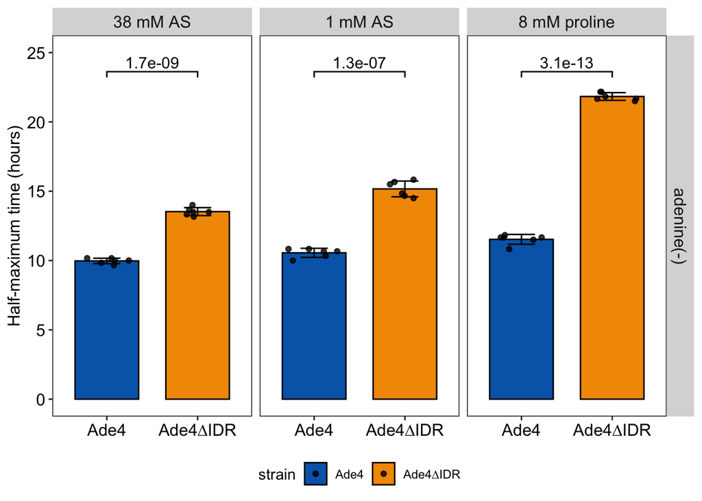

```r
# adenine(-)のデータ
mean_halfmaxtime_woade2 <- mean_halfmaxtime %>%
  filter(adenine == "adenine(-)") %>%
  ggplot(aes(x = strain, y = mean_ht, fill=strain)) +
  geom_col(color="black", width = 0.7) +
  geom_errorbar(aes(ymin = mean_ht - sd_ht, ymax = mean_ht + sd_ht, width = 0.3)) +
  geom_jitter(halfmaxtime[halfmaxtime$adenine == "adenine(-)",],
              mapping=aes(x=strain, y= halfmaxtime), color="black",
              size = 1.5, alpha=0.8,
              height = 0, width = 0.3) + # height = 0にしないとy軸上に散らばり不正確になる

  geom_signif(data=halfmaxtime[halfmaxtime$adenine == "adenine(-)",],
              mapping=aes(x=strain,y=halfmaxtime),
              comparisons = list(c("Ade4","Ade4∆IDR")),
              test = "t.test",map_signif_level = FALSE, step_increase = 0, y_position = 23, textsize = 4,
              test.args= list(alternative = "two.sided", var.equal = FALSE, paired=F)) +

  scale_fill_manual(values = c("#0068b7","#f39800"))+
  ylab("Half-maximum time (hours)") +
  xlab(NULL)+
  ylim(0,25)+
  theme( axis.title.y = element_text(size=12), axis.text.y = element_text(size=12,color = "black"),
         axis.text.x = element_text(size=12,color = "black"),
         strip.text = element_text(size = 12)
         ,legend.position = "bottom"
         ,panel.border = element_rect(fill = NA, linewidth = 0.5)
         ,panel.background = element_blank()) +
  facet_grid(adenine ~ nitrogen)
mean_halfmaxtime_woade2
```

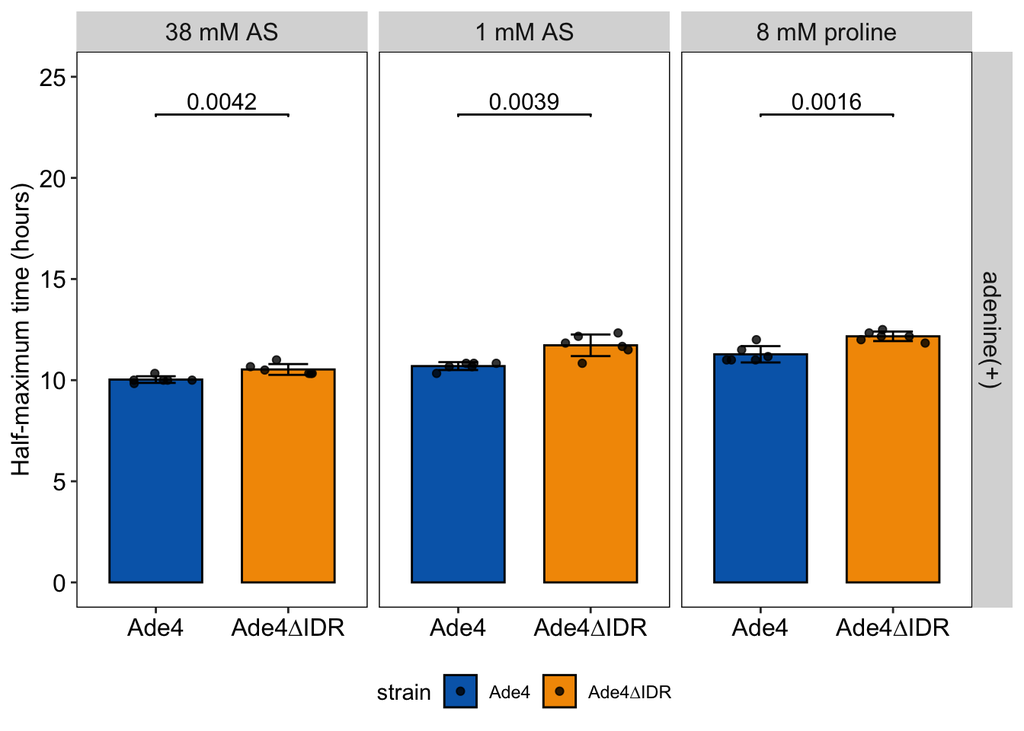

```r
# adenine(+)のデータ
mean_halfmaxtime_wade2 <- mean_halfmaxtime %>%
  filter(adenine == "adenine(+)") %>%
  ggplot(aes(x = strain, y = mean_ht, fill=strain)) +
  geom_col(color="black", width = 0.7) +
  geom_errorbar(aes(ymin = mean_ht - sd_ht, ymax = mean_ht + sd_ht, width = 0.3)) +
  geom_jitter(halfmaxtime[halfmaxtime$adenine == "adenine(+)",],
              mapping=aes(x=strain, y= halfmaxtime), color="black",
              size = 1.5, alpha=0.8,
              height = 0, width = 0.3) + # height = 0にしないとy軸上に散らばり不正確になる

  geom_signif(data=halfmaxtime[halfmaxtime$adenine == "adenine(+)",],
              mapping=aes(x=strain,y=halfmaxtime),
              comparisons = list(c("Ade4","Ade4∆IDR")),
              test = "t.test",map_signif_level = FALSE, step_increase = 0, y_position = 23, textsize = 4,
              test.args= list(alternative = "two.sided", var.equal = FALSE, paired=F)) +

  scale_fill_manual(values = c("#0068b7","#f39800"))+
  ylab("Half-maximum time (hours)") +
  xlab(NULL)+
  ylim(0,25)+
  theme( axis.title.y = element_text(size=12), axis.text.y = element_text(size=12,color = "black"),
         axis.text.x = element_text(size=12,color = "black"),
         strip.text = element_text(size = 12)
          ,legend.position = "bottom"
         ,panel.border = element_rect(fill = NA, linewidth  = 0.5)
         ,panel.background = element_blank()) +
  facet_grid(adenine ~ nitrogen)
mean_halfmaxtime_wade2
```